# Tipps ’n Tricks für Übungsaufgabe 3 (R)

**Packages einladen**

```r
pacman::p_load(tidyverse, haven, sjPlot, sjmisc,texreg, car,psych, knitr, broom, ggpubr, tidytemplate)
```

**Datensatz einladen.**

```r
allbus <- read_spss("allbus2014.sav")
allb_r <-allbus %>%
  select(V84, V86, V81, V420, V98, V118, V269, V103, V7, V13, V14,
         V16, V20, V21, V22, V25, V30,V31, V494, V9, V209, V279,
         V71, V711, V216, V215, V495, V513, V514, V377) %>%
  rename(alter = V84,  bildung = V86,  geschl = V81, einkommen = V420,
         arbeitsstd = V118, keineberufsausbildung = V98, beruf = V103,
         westost = V7, internet = V14,computer = V16,essen = V20,
         besuchfreunde = V21,besuchfamilie = V22,kunst = V25,theater = V30,
         museum = V31,haushaltseinkommen = V494,wirtschaftslage = V9,
         fernsehenmin= V71,dauerbildung = V711,demzufr = V216,
         linksrechts = V215,prokopfeink = V495,krankengeldhh = V513,
         elterngeldhh = V514,gebd = V377) %>%
  mutate(alter0 = alter - 18,
          alter0quad = alter0*alter0,
          bildung_rec = ifelse(bildung == 6 | bildung == 7, 0, bildung - 1),
          geschl_rec = ifelse(geschl == 2, 0, 1),
          ganztags = ifelse(beruf == 1, 1, 0),
          halbtags = ifelse(beruf == 2, 1, 0),
          west = ifelse(westost == 1, 1, 0),
          immigrant = ifelse(gebd == 2, 1, 0))
```

## Modelle untersuchen mit `broom`

Lasst uns zunächst einmal eine Beispielsregression erstellen: Versuchen wir Demokratiefzufriedenheit mit der Einschätzung der Wirtschaftslage hervorzusagen und speichern wir dieses Modell in `lmfit` ab.

```r
lmfit <- lm(demzufr ~ wirtschaftslage, allb_r)
htmlreg(lmfit, doctype = F)
```

Statistical models

|  | **Model 1** |  |
| --- | --- | --- |
| (Intercept) | 1.76*** |  |
|  | (0.06) |  |
| wirtschaftslage | 0.40*** |  |
|  | (0.02) |  |
| R<sup>2</sup> | 0.08 |  |
| Adj. R<sup>2</sup> | 0.08 |  |
| Num. obs. | 3448 |  |
| RMSE | 1.09 |  |
| p < 0.001, p < 0.01, p < 0.05 |  |  |

Mit dem package `broom` können Modelle sehr einfach auseinander genommen werden.

`tidy`: Erstellt einen Datenrahmen, der die statistischen Ergebnisse des Modells zusammenfasst. Dies beinhaltet Koeffizienten und p-Werte für jeden Term in einer Regression

```r
tidy(lmfit) %>%
  kable()
```

| term | estimate | std.error | statistic | p.value |
| --- | --- | --- | --- | --- |
| (Intercept) | 1.7626000 | 0.0601177 | 29.31916 | 0 |
| wirtschaftslage | 0.4023625 | 0.0235822 | 17.06213 | 0 |

`glance`: Erstellt eine einzeilige Zusammenfassung des Modells. Dies enthält normalerweise Werte wie $R^2$, angepasstes $R^2$ und Standardschätzfehler, die einmal für das gesamte Modell berechnet werden.

```r
glance(lmfit) %>%
  kable()
```

|  | r.squared | adj.r.squared | sigma | statistic | p.value | df | logLik | AIC | BIC | deviance | df.residual |
| --- | --- | --- | --- | --- | --- | --- | --- | --- | --- | --- | --- |
| value | 0.0778986 | 0.077631 | 1.08803 | 291.1162 | 0 | 2 | -5182.404 | 10370.81 | 10389.25 | 4079.41 | 3446 |

`augment`: Modelldiagnostik. Fitted Values, Residuen, etc.

```r
augment(lmfit) %>%
  head() %>%
  kable()
```

| .rownames | demzufr | wirtschaftslage | .fitted | .se.fit | .resid | .hat | .sigma | .cooksd | .std.resid |
| --- | --- | --- | --- | --- | --- | --- | --- | --- | --- |
| 1 | 2 | 2 | 2.567325 | 0.0210681 | -0.5673250 | 0.0003749 | 1.088145 | 0.00005100882 | -0.5215216 |
| 2 | 2 | 2 | 2.567325 | 0.0210681 | -0.5673250 | 0.0003749 | 1.088145 | 0.00005100882 | -0.5215216 |
| 3 | 4 | 2 | 2.567325 | 0.0210681 | 1.4326750 | 0.0003749 | 1.087914 | 0.00032529456 | 1.3170070 |
| 4 | 2 | 2 | 2.567325 | 0.0210681 | -0.5673250 | 0.0003749 | 1.088145 | 0.00005100882 | -0.5215216 |
| 5 | 2 | 3 | 2.969688 | 0.0229584 | -0.9696875 | 0.0004452 | 1.088063 | 0.00017698633 | -0.8914305 |
| 6 | 5 | 2 | 2.567325 | 0.0210681 | 2.4326750 | 0.0003749 | 1.087398 | 0.00093788508 | 2.2362714 |

## Residuenanalyse mit `sjPlot`

Für die Residuenanalyse lassen wir uns mit Hilfe von `augment` die nötigen Werte ausgeben. Diese speichen wir in `diag_mod` ab.

```r
diag_mod <- augment(lmfit)
```

Wir benutzen das `sjPlot` package um Scatterplots zu erstellen. Die dazugehörige Funktion `plot_scatter` ist auch gut mit der `%>%` benutzbar.

Wir interessieren uns allerdings vor allem für **Scatterplots**.

Ein einfaches Scatterplot erstellen wir mit dem folgenden Befehl

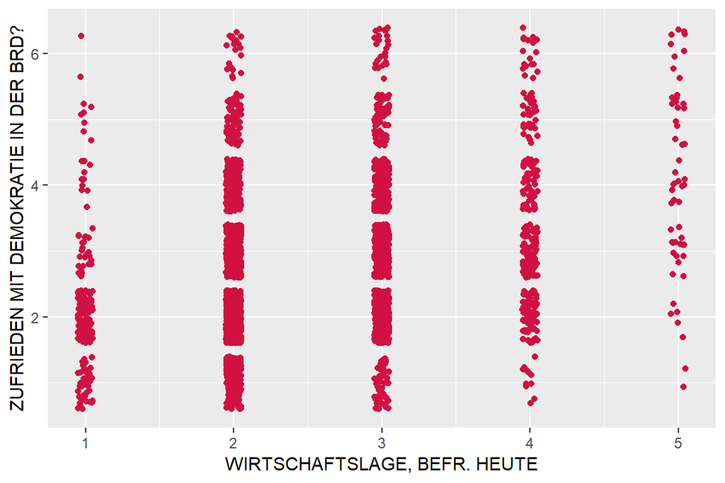

```r
allb_r %>% #Datensatz
  plot_scatter(wirtschaftslage, demzufr) #x und y definieren
```

Jetzt fügen wir noch einige Optionen hinzu:

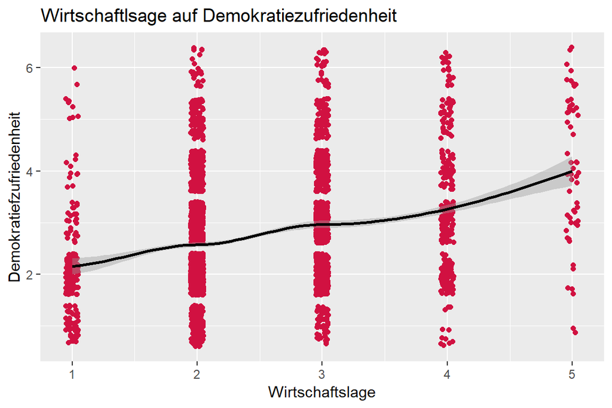

```r
allb_r %>% #Datensatz
  plot_scatter(wirtschaftslage, demzufr, #x und y definieren
               fit.line = "loess",  #zeige eine loess Kurve
               show.ci = T,         #zeige zusätzliche das Konfidenzintervall
               title = "Wirtschaftlsage auf Demokratiezufriedenheit",   #Titel der Grafik
               axis.titles = c("Wirtschaftslage",
                         "Demokratiefzufriedenheit")) #Ein Vektor mit den Namen der Achsen
```

Führen wir jetzt die Diagnostik durch. Wir benutzen dafür die Variable `.resid` aus dem Diagnostikdatensatz.

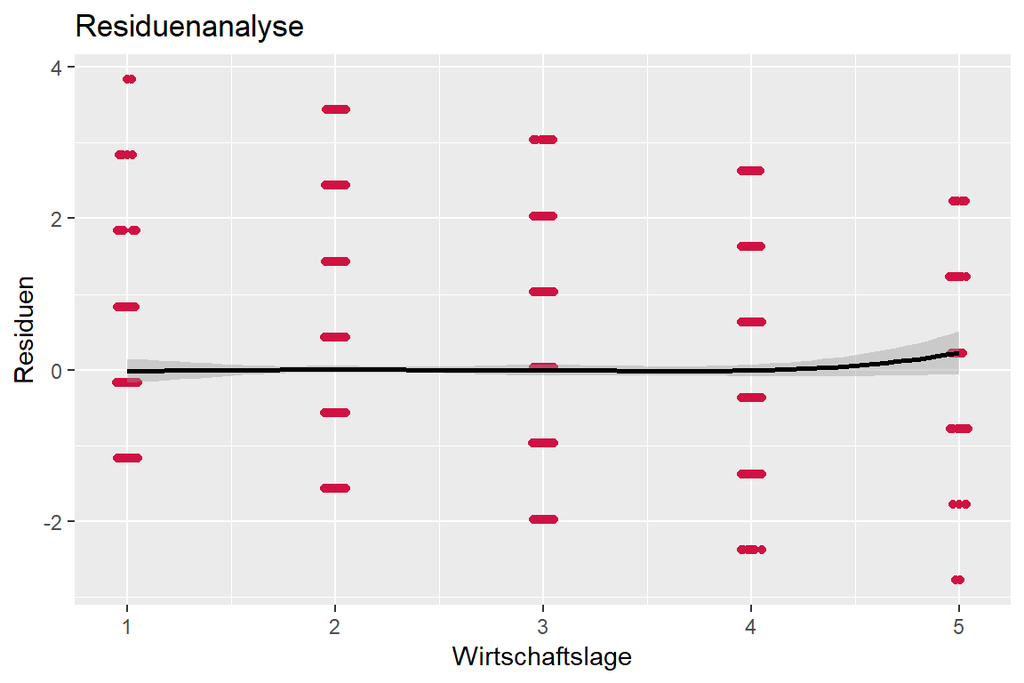

```r
diag_mod %>% #Datensatz
  plot_scatter(wirtschaftslage, .resid, #x und y definieren
               fit.line = "loess",  #zeige eine loess Kurve
               show.ci = T,         #zeige zusätzliche das Konfidenzintervall
               title = "Residuenanalyse",
               axis.titles = c("Wirtschaftslage", "Residuen"))
```

Wir können auch die Variable `std.resid` benutzen für die standardisierten Residuen.

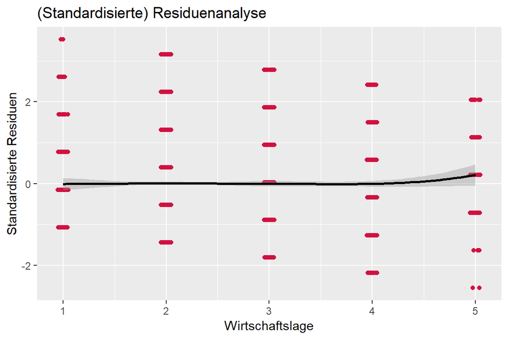

```r
diag_mod %>%
  plot_scatter(wirtschaftslage, .std.resid, #x und y definieren
               fit.line = "loess",  #zeige eine loess Kurve
               show.ci = T,         #zeige zusätzliche das Konfidenzintervall
               title = "(Standardisierte) Residuenanalyse",
               axis.titles = c("Wirtschaftslage",
                        "Standardisierte Residuen"))
```

Das Argument `jitter = T` macht den Plot ein bisschen ansehnlicher

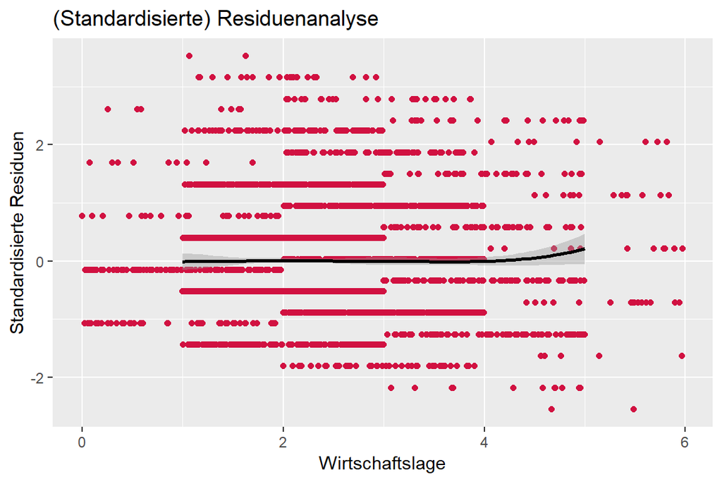

```r
diag_mod %>%
  plot_scatter(wirtschaftslage, .std.resid, #x und y definieren
               jitter = T,          # jittern macht den Plot bisschen ansehnlicher
               fit.line = "loess",  #zeige eine loess Kurve
               show.ci = T,         #zeige zusätzliche das Konfidenzintervall
         title = "(Standardisierte) Residuenanalyse",
         axis.titles = c("Wirtschaftslage",
                        "Standardisierte Residuen"))
```

## Testen der A3

Beim testen der A3, werden die absoluten Werte der Residuen betrachtet, da sich negative und positive Werte über die gesamte Regressionsgerade weitestgehend ausmitteln. Erstellen wir also zunächst eine Residuenvariable `std.resid.abs`, welche diese absoluten Werte beinhaltet:

```r
diag_mod <- diag_mod %>%
  mutate(.std.resid.abs = abs(.std.resid))
```

Korrelationen können wir mit der Funktion `corstar` aus dem `tidytemplate` package testen. Diese nimmt einen Datensatz und erechnet einfache Korrelationen und Signifikanzen. Sollte die Funktion aus irgendeinem Grunde nicht funktionieren, könnt ihr auch `cor` benutzen.

```r
diag_mod %>%
  select(wirtschaftslage, .std.resid.abs) %>%
  corstar() %>%
  kable()
```

|  | wirtschaftslage | .std.resid.abs |
| --- | --- | --- |
| wirtschaftslage | 1.000*** | 0.120*** |
|  | (0.000) | (0.000) |
| .std.resid.abs | 0.120*** | 1.000*** |
|  | (0.000) | (0.000) |

Ansonsten könnten wir auch `cor.test` benutzen:

```r
cor.test(diag_mod$wirtschaftslage, diag_mod$.std.resid.abs)
```

```
##
##  Pearson's product-moment correlation
##
## data:  diag_mod$wirtschaftslage and diag_mod$.std.resid.abs
## t = 7.0928, df = 3446, p-value = 0.000000000001588
## alternative hypothesis: true correlation is not equal to 0
## 95 percent confidence interval:
##  0.08692039 0.15272173
## sample estimates:
##       cor
## 0.1199528
```

Wir könnten aber auch einfach eine Regression berechnen und diese dann mit `plot_model` darstellen:

```r
resid_mod <- lm(.std.resid.abs ~ wirtschaftslage, data = diag_mod)
htmlreg(resid_mod, doctype = F)
```

Statistical models

|  | **Model 1** |  |
| --- | --- | --- |
| (Intercept) | 0.58*** |  |
|  | (0.03) |  |
| wirtschaftslage | 0.09*** |  |
|  | (0.01) |  |
| R<sup>2</sup> | 0.01 |  |
| Adj. R<sup>2</sup> | 0.01 |  |
| Num. obs. | 3448 |  |
| RMSE | 0.60 |  |
| p < 0.001, p < 0.01, p < 0.05 |  |  |

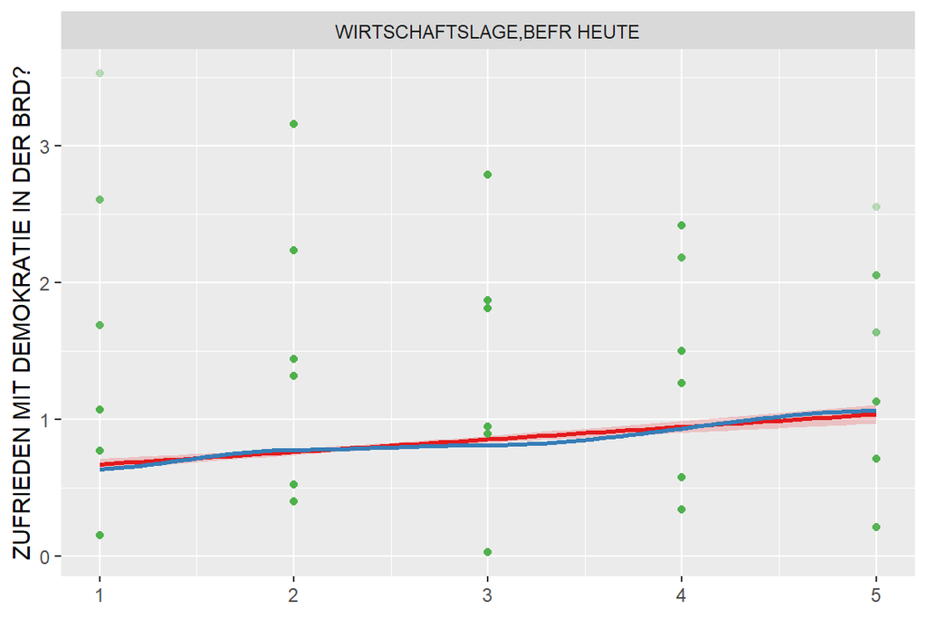

```r
plot_model(resid_mod, show.data = T)
```

## Testen der A5

Wir können ein Histogramm darstellen indem wir die gewünschte Variable auswählen und in die Funktion `sjplot` pipen. Die Optionen `fun = frq` und `type = "hist"` erstellt dann den gewünschten Plot. Mit den Optionen `normal.curve = TRUE` lassen wir uns eine Normalverteilung zeigen und `show.mean = TRUE` zeigt uns den Mittelwert.

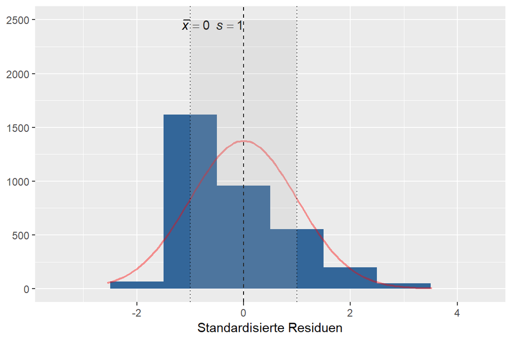

```r
diag_mod %>%
  select(.std.resid) %>%
  sjplot(fun = "frq",        #univariate Zähldaten
        type = "hist",       #Histogramm
        normal.curve = TRUE, #Normalverteilung
        show.mean = TRUE,    #Mittelwert darstellen
        axis.title = "Standardisierte Residuen") #Namen für x-Achse
```

Um zu sehen ob die Normalverteilung in Ordnung ist sollten wir uns zusätzlich noch die Skewness und Kurtosis der Residuenverteilung anzeigen lassen. Die Funktion `describe` gibt unter anderem diese Kennwerte aus.

```r
diag_mod %>%
  select(.resid, .std.resid) %>%
  describe() %>%
  select(n, mean, sd, skew , kurtosis) %>%
  kable()
```

|  | n | mean | sd | skew | kurtosis |
| --- | --- | --- | --- | --- | --- |
| .resid | 3448 | 0.0000000 | 1.087873 | 0.7437229 | 0.3053701 |
| .std.resid | 3448 | 0.0000022 | 1.000174 | 0.7436318 | 0.3054769 |

Statistisch lässt sich die Normalverteilung auch mit der `shapiro.test` Funktion testen, welche de `Shapiro-Wilk Normalitätstest` berechnet. Dieser sollte nicht signifikant werden, wenn von einer Normalverteilung ausgegangen werden soll.

```r
shapiro.test(diag_mod$.std.resid)
```

```
##
##  Shapiro-Wilk normality test
##
## data:  diag_mod$.std.resid
## W = 0.94039, p-value < 0.00000000000000022
```

Eine letzte Option wäre es noch die Funktion `ggqqplot` aus dem `ggpubr` package zu benutzen. Hier müssen noch alle Variablen vorher als `numeric` definiert werden, da die Funktion nicht mit gelabellelten Daten umgehen kann.

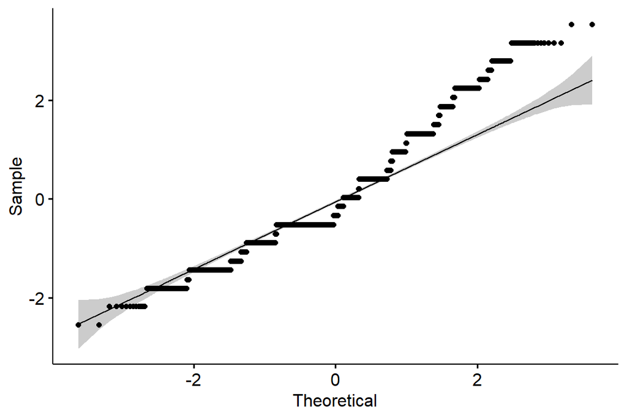

```r
diag_mod %>%
  mutate_all(as.numeric) %>%
  ggqqplot(x = ".std.resid")
```

Fabio Votta

15 November 2018